# Proyecto Final — Derivados · Apple (AAPL): Bono Convertible Sintético con volatilidad GARCH

**Base metodológica:** caso *Molson Coors Brewing Co.: Valuing a Convertible Bond* (NE90-06-107) + clase de GARCH (Hull, 11.ª ed., caps. 13, 22 y 23) **Formato de entrega:** dashboard tipo FINA 405 (tarjetas KPI + pestañas), HTML autocontenido **Datos:** Refinitiv / LSEG (sesión abierta con tu App Key)

**Lógica.** Apple no tiene convertibles: tomamos un bono real de Apple como **bono puro** (su YTM es la tasa de descuento, el análogo del 5.75% de Molson) y preguntamos qué cupón pagaría Apple si emitiera hoy ese bono como **convertible a 6 años**. La versión 2 agrega el módulo de la clase: **GARCH(1,1) decide qué volatilidad usar** en la opción de conversión y el **árbol CRR** mide cuánto vale poder convertir antes (opción americana).

| Paso | Caso Molson / Clase GARCH | Proyecto AAPL |
| --- | --- | --- |
| 1 | Hull 23.1–23.5: histórica, EWMA, GARCH por MLE | Estimación con 5 años de AAPL (Refinitiv), validación con `arch` |
| 2 | Hull 23.4: elegir modelo (LL, AIC/BIC, Ljung-Box) | Tabla comparativa |
| 3 | Hull 23.6: volatilidad promedio para la vida de la opción | σ GARCH promedio a 6 años → entra al convertible |
| 4 | Hull 23.7: correlaciones | AAPL vs S&P 500 con EWMA |
| 5 | Hull 22.6 y 22.8: Monte Carlo GARCH, VaR y Kupiec | Abanico de precios, VaR 99% y back testing |
| 6 | Exhibit 2 del caso | Opción de conversión: BS, CRR americano y MC-GARCH (Duan) |
| 7 | Exhibit 3 | Cupón que deja el convertible a la par |
| 8 | Sensibilidades del caso | Prima × volatilidad |
| 9 | Exhibits 1 y 4 | Call spread: note hedge 25% + warrant 60% |
| 10 | Señal de volatilidad de la clase | σ GARCH vs σ implícita y straddle ATM |

> **Correr:** *Kernel → Restart & Run All*. Si un campo de Refinitiv no responde, el dato se marca **⚠ respaldo** en el dashboard.

```python
# ---- Silenciar NotOpenSSLWarning (urllib3 v2 + LibreSSL en macOS) — debe ir primero ----
import os, warnings
warnings.filterwarnings("ignore", message=r".*urllib3 v2 only supports OpenSSL.*")
warnings.filterwarnings("ignore", category=UserWarning, module=r"urllib3")
os.environ["PYTHONWARNINGS"] = "ignore:urllib3 v2 only supports OpenSSL"
```

```python
# ---- Instalación de paquetes (solo si faltan) ----
import subprocess, sys, importlib
for _mod, _pkg in [("plotly", "plotly"), ("scipy", "scipy"), ("arch", "arch"), ("statsmodels", "statsmodels"),
                   ("openpyxl", "openpyxl"), ("nbconvert", "nbconvert")]:
    try:
        importlib.import_module(_mod)
    except ImportError:
        subprocess.check_call([sys.executable, "-m", "pip", "install", "-q", _pkg])
```

```python
import numpy as np, pandas as pd, datetime as dt, json
from scipy.stats import norm, chi2
from scipy.optimize import brentq, minimize
from scipy.signal import lfilter
import plotly.graph_objects as go
from plotly.subplots import make_subplots
warnings.filterwarnings("ignore")
pd.set_option("display.float_format", lambda x: f"{x:,.4f}")
```

## 1 · Parámetros del proyecto

```python
AUTORES   = "Equipo 3"
CURSO     = "Productos Derivados y Administración de Riesgos Corporativos · EGADE"
HOY       = dt.date.today()
TICKER_RIC = "AAPL.O"
BENCH_RIC  = ".SPX"                      # para la correlación (Hull 23.7)

BONO = dict(nombre="Apple Inc 4.500% Notes due 12-May-2032", cusip="037833FA3", isin="US037833FA32",
            cupon=0.045, vencimiento="2032-05-12", emision="2025-05-12", monto_usd=1_000_000_000,
            frecuencia=2, rango="Senior Unsecured", call="Make-whole; par call desde 12-Mar-2032")

UNIVERSO_RESPALDO = [
    dict(nombre="AAPL 4.000% 10-May-2028", cusip="037833ET3", isin="US037833ET32", cupon=0.0400, vencimiento="2028-05-10"),
    dict(nombre="AAPL 4.150% 10-May-2030", cusip="037833EU0", isin="US037833EU05", cupon=0.0415, vencimiento="2030-05-10"),
    dict(nombre="AAPL 4.500% 12-May-2032", cusip="037833FA3", isin="US037833FA32", cupon=0.0450, vencimiento="2032-05-12"),
    dict(nombre="AAPL 3.350% 08-Aug-2032", cusip="037833EP1", isin="US037833EP10", cupon=0.0335, vencimiento="2032-08-08"),
]

# Convertible (caso)
PLAZO_CONV      = 6.0
PRIMA_CONV      = 0.25
PRIMA_WARRANT   = 0.60
AJUSTE_VOL_WARR = -0.02
PRIMAS_SENS     = [0.10, 0.15, 0.20, 0.25, 0.30, 0.40, 0.50, 0.60]
USAR_DIVIDENDO  = True
MONTO_EMISION   = None

# Volatilidad: cuál entra al convertible → "GARCH" (promedio a 6 años), "HIST" (1 año), "EWMA" o "IV"
VOL_FUENTE      = "GARCH"

# Módulo GARCH (clase)
YEARS        = 5
LAMBDA_EWMA  = 0.94
HORIZON_DAYS = 126            # pronóstico de precio y opción ATM (~6 meses)
N_SIM        = 5000
MU_ANUAL     = 0.08           # rendimiento esperado SUPUESTO (solo para el pronóstico del precio)
SEED         = 123
UMBRAL_SENAL = 0.10
IV_MANUAL    = None           # p. ej. 0.265 si quieres fijar la implícita ATM a mano
N_ARBOL      = 500

# Respaldo — SOLO si Refinitiv no devuelve el dato (se marca ⚠)
RESPALDO = dict(S=347.10, precio_bono=96.894, div_yield=0.0032, iv=0.265,
                ust={2:0.047, 3:0.048, 5:0.0492, 7:0.050, 10:0.0508, 30:0.053})
CARPETA = "."
```

## 2 · Conexión a Refinitiv y utilidades

```python
import lseg.data as ld
from datetime import datetime
from getpass import getpass

APP_KEY = getpass("App Key: ")
USERNAME = input("Usuario LSEG: ")
PASSWORD = getpass("Contraseña LSEG: ")

API = None
try:
    grant = ld.session.platform.GrantPassword(username=USERNAME, password=PASSWORD)
    definicion = ld.session.platform.Definition(app_key=APP_KEY, grant=grant, signon_control=True)
    session = definicion.get_session()
    session.open()
    ld.session.set_default(session)
    print("Estado:", session.open_state, "| Hora:", datetime.now())
    rd = ld
    prueba = rd.get_data("AAPL.O", ["TR.PriceClose"])
    if prueba is not None and not prueba.empty:
        API = "rd"
        print("CONECTADO: AAPL =", prueba.iloc[0, -1])
except Exception as e:
    print("ERROR DE CONEXION:", e)
PASSWORD = None
print("API:", API)
```

```
Estado: OpenState.Opened | Hora: 2026-11-03 21:53:33.609575
CONECTADO: AAPL = 331.9
API: rd
```

[output not shown]

```python
FUENTES = {}

def registra(clave, valor, fuente):
    FUENTES[clave] = fuente
    return valor

def num(v):
    try:
        return float(v)
    except Exception:
        return np.nan

def en_pct(v):
    v = num(v)
    return v / 100 if pd.notna(v) else v

def _ok(v):
    if v is None:
        return False
    return str(v).strip() not in ("", "<NA>", "nan", "None")

def get_data(instr, fields):
    if API is None:
        return pd.DataFrame()
    if isinstance(instr, str):
        instr = [instr]
    if isinstance(fields, str):
        fields = [fields]
    try:
        df = rd.get_data(list(instr), list(fields))
        return pd.DataFrame() if df is None else df
    except Exception as e:
        print("  sin dato", fields, str(e)[:80])
        return pd.DataFrame()

def first_value(instr, fields):
    for f in fields:
        df = get_data(instr, [f])
        if df.shape[1] >= 2 and len(df) > 0:
            v = df.iloc[0, -1]
            if _ok(v):
                return v, f
    return None, None

def batch_value(instrs, fields):
    out = {i: np.nan for i in instrs}
    for f in fields:
        faltan = [i for i in instrs if pd.isna(out[i])]
        if len(faltan) == 0:
            break
        df = get_data(faltan, [f])
        if df.shape[1] < 2:
            continue
        for ins, v in zip(df.iloc[:, 0], df.iloc[:, -1]):
            if ins in out and _ok(v):
                out[ins] = num(v)
    return out

def get_history(ric, start, end=None):
    if API is None:
        return pd.Series(dtype=float)
    end = end or HOY.isoformat()
    for campos in (["TRDPRC_1"], ["TR.PriceClose"]):
        try:
            df = rd.get_history(universe=ric, fields=campos, interval="daily", start=start, end=end)
            df = df.apply(pd.to_numeric, errors="coerce").dropna(axis=1, how="all")
            if not df.empty:
                s = df.iloc[:, 0].dropna()
                s.index = pd.to_datetime(s.index)
                return s
        except Exception as e:
            print("  historia", ric, str(e)[:80])
    return pd.Series(dtype=float)

print("Utilidades listas. API =", API)
```

```
Utilidades listas. API = rd
```

## 3 · Motor de valuación: Black-Scholes-Merton, bonos, árbol CRR y GARCH

```python
# ---------- Black-Scholes-Merton
def bsm(S, K, r, sig, T, q=0.0):
    S = np.asarray(S, float); sq = sig*np.sqrt(T)
    d1 = (np.log(S/K) + (r - q + 0.5*sig**2)*T)/sq; d2 = d1 - sq
    dq, dr = np.exp(-q*T), np.exp(-r*T)
    c = S*dq*norm.cdf(d1) - K*dr*norm.cdf(d2); p = c - S*dq + K*dr
    return dict(call=c, put=p, d1=d1, d2=d2, delta_c=dq*norm.cdf(d1), delta_p=dq*(norm.cdf(d1)-1),
                gamma=dq*norm.pdf(d1)/(S*sq), vega=S*dq*norm.pdf(d1)*np.sqrt(T)/100,
                theta_c=(-S*dq*norm.pdf(d1)*sig/(2*np.sqrt(T)) - r*K*dr*norm.cdf(d2) + q*S*dq*norm.cdf(d1))/365,
                rho_c=K*T*dr*norm.cdf(d2)/100)

# ---------- Bonos
def flujos(cupon, T, face=1000, f=2):
    n = int(np.ceil(T*f - 1e-9)); t = np.sort(T - np.arange(n)/f); t = t[t > 1e-9]
    cf = np.full(len(t), face*cupon/f); cf[-1] += face
    return t, cf

def valor_bono(cupon, y, T, face=1000, f=2, limpio=True):
    t, cf = flujos(cupon, T, face, f); sucio = np.sum(cf/(1+y/f)**(f*t))
    if not limpio: return sucio
    return sucio - (face*cupon/f*(1 - t[0]*f) if t[0] < 1/f else 0.0)

def ytm_de_precio(precio_100, cupon, T, f=2):
    return brentq(lambda y: valor_bono(cupon, y, T, 100, f) - precio_100, -0.05, 0.5)

def dur_conv(cupon, y, T, f=2):
    t, cf = flujos(cupon, T, 100, f); pv = cf/(1+y/f)**(f*t); P = pv.sum()
    mac = np.sum(t*pv)/P
    return mac, mac/(1+y/f), np.sum(t*(t+1/f)*pv)/(P*(1+y/f)**2)

def cupon_para_valor(objetivo, y, T, face=1000, f=2):
    v0 = valor_bono(0.0, y, T, face, f, False); v1 = valor_bono(0.01, y, T, face, f, False)
    return (objetivo - v0)/(v1 - v0)*0.01

def valuar_convertible(S, prima, r, sig, T, y, q=0.0, face=1000):
    K = S*(1+prima); n = face/K; o = bsm(S, K, r, sig, T, q)
    opc = o["call"]*n; piso = face - opc
    return dict(K=K, n=n, call_acc=float(o["call"]), put_acc=float(o["put"]), delta=float(o["delta_c"]),
                opcion_bono=float(opc), piso=float(piso), cupon=cupon_para_valor(piso, y, T, face), greeks=o)

# ---------- Árbol CRR (Hull cap. 13) con griegas
def crr(S0, K, r, sigma, T, N=500, tipo="call", americana=True, q=0.0):
    dt_ = T/N; u_ = np.exp(sigma*np.sqrt(dt_)); d_ = 1/u_
    p = (np.exp((r-q)*dt_) - d_)/(u_ - d_); disc = np.exp(-r*dt_); sg = 1 if tipo == "call" else -1
    niveles = [None]*3; j = np.arange(N+1)
    V = np.maximum(sg*(S0*u_**(N-j)*d_**j - K), 0.0)
    for i in range(N-1, -1, -1):
        k = np.arange(i+1); cont = disc*(p*V[:i+1] + (1-p)*V[1:i+2])
        V = np.maximum(cont, np.maximum(sg*(S0*u_**(i-k)*d_**k - K), 0.0)) if americana else cont
        if i <= 2: niveles[i] = V
    return V[0], niveles, u_, d_, dt_

def griegas_crr(S0, K, r, sigma, T, N=500, tipo="call", americana=True, q=0.0):
    precio, niv, u_, d_, dt_ = crr(S0, K, r, sigma, T, N, tipo, americana, q)
    f0, f1, f2 = niv[0][0], niv[1], niv[2]
    delta = (f1[0]-f1[1])/(S0*u_ - S0*d_)
    gamma = ((f2[0]-f2[1])/(S0*u_**2 - S0) - (f2[1]-f2[2])/(S0 - S0*d_**2))/(0.5*(S0*u_**2 - S0*d_**2))
    return dict(precio=precio, delta=delta, gamma=gamma, theta=(f2[1]-f0)/(2*dt_)/365,
                vega=crr(S0, K, r, sigma+0.01, T, N, tipo, americana, q)[0] - precio,
                rho=crr(S0, K, r+0.01, sigma, T, N, tipo, americana, q)[0] - precio)

# ---------- GARCH(1,1), EWMA y verosimilitud (Hull 23.2–23.5); rendimientos en %
def var_garch(params, u, v0=None):
    omega, alpha, beta = params
    v0 = np.var(u) if v0 is None else v0
    y, _ = lfilter([1.0], [1.0, -beta], omega + alpha*u[:-1]**2, zi=[beta*v0])
    return np.r_[v0, y]

def var_ewma(u, lam=LAMBDA_EWMA): return var_garch((0.0, 1-lam, lam), u, v0=np.var(u[:30]))
def loglik(v, u): return -0.5*np.sum(np.log(2*np.pi) + np.log(v) + u**2/v)
def vol_anual(v): return np.sqrt(252*np.asarray(v))/100

def ajustar_garch(u):
    v = np.var(u)
    res = minimize(lambda p: -loglik(var_garch(p, u), u), [v*0.03, 0.08, 0.90], method="SLSQP",
                   bounds=[(1e-6, None), (1e-4, 0.5), (0.30, 0.9998)],
                   constraints=({"type": "ineq", "fun": lambda p: 0.9999 - p[1] - p[2]},),
                   options={"maxiter": 500, "ftol": 1e-10})
    return res.x

def kupiec(x, N, p):
    if x == 0: lr = -2*N*np.log(1-p)
    else:
        ph = x/N; lr = -2*((N-x)*np.log((1-p)/(1-ph)) + x*np.log(p/ph))
    return float(1 - chi2.cdf(lr, 1))
```

## 4 · Validación: replicar el caso Molson Coors (Exhibits 2, 3 y 4)

```python
m = valuar_convertible(87.61, 0.25, 0.0446, 0.23, 6, 0.0575, q=0.0)
w = bsm(87.61, 87.61*1.60, 0.0446, 0.21, 6)
VALID = pd.DataFrame([
    ["Precio de conversión", 109.51, m["K"]], ["Acciones por bono", 9.13, m["n"]],
    ["Call por acción (25%)", 21.0, m["call_acc"]], ["Delta call", 0.64, m["delta"]],
    ["Put por paridad", 17.2, m["put_acc"]], ["Opción de conversión/bono", 191.5, m["opcion_bono"]],
    ["Valor bono puro", 808.5, m["piso"]], ["Cupón a la par (%)", 1.93, m["cupon"]*100],
    ["Warrant 60% por acción", 11.4, float(w["call"])], ["Costo note hedge (USD M)", 110.0, m["call_acc"]*5.25],
    ["Ingreso warrants (USD M)", 59.0, float(w["call"])*5.25],
], columns=["Concepto", "Caso", "Modelo"])
VALID["Diferencia"] = VALID["Modelo"] - VALID["Caso"]
VALID
```

|  | Concepto | Caso | Modelo | Diferencia |
| --- | --- | --- | --- | --- |
| 0 | Precio de conversión | 109.5100 | 109.5125 | 0.0025 |
| 1 | Acciones por bono | 9.1300 | 9.1314 | 0.0014 |
| 2 | Call por acción (25%) | 21.0000 | 20.9735 | -0.0265 |
| 3 | Delta call | 0.6400 | 0.6408 | 0.0008 |
| 4 | Put por paridad | 17.2000 | 17.1640 | -0.0360 |
| 5 | Opción de conversión/bono | 191.5000 | 191.5167 | 0.0167 |
| 6 | Valor bono puro | 808.5000 | 808.4833 | -0.0167 |
| 7 | Cupón a la par (%) | 1.9300 | 1.9306 | 0.0006 |
| 8 | Warrant 60% por acción | 11.4000 | 11.4221 | 0.0221 |
| 9 | Costo note hedge (USD M) | 110.0000 | 110.1108 | 0.1108 |
| 10 | Ingreso warrants (USD M) | 59.0000 | 59.9659 | 0.9659 |

## 5 · Universo de bonos USD de Apple en Refinitiv y selección

```python
def buscar_bonos_aapl():
    if API != "rd": return pd.DataFrame()
    sel = "RIC,ISIN,CUSIP,IssuerLegalName,CouponRate,MaturityDate,IssueDate,FaceIssuedTotal,RCSCurrencyLeaf"
    for flt in ["IsActive eq true and RCSCurrencyLeaf eq 'US Dollar'", "IsActive eq true", None]:
        try:
            kw = dict(view=rd.discovery.Views.GOV_CORP_INSTRUMENTS, query="Apple Inc", select=sel, top=300)
            if flt: kw["filter"] = flt
            df = rd.discovery.search(**kw)
            if df is not None and not df.empty:
                df = df[df.astype(str).agg(" ".join, axis=1).str.contains("Apple Inc", case=False)]
                if "RCSCurrencyLeaf" in df: df = df[df["RCSCurrencyLeaf"].astype(str).str.contains("US Dollar")]
                if not df.empty: return df
        except Exception as e:
            print("  · discovery.search:", str(e)[:100])
    return pd.DataFrame()

raw = buscar_bonos_aapl()
if not raw.empty:
    U = pd.DataFrame({
        "ric": raw.get("RIC"), "isin": raw.get("ISIN"), "cusip": raw.get("CUSIP"),
        "cupon": pd.to_numeric(raw.get("CouponRate"), errors="coerce")/100,
        "vencimiento": pd.to_datetime(raw.get("MaturityDate"), errors="coerce").dt.date,
        "monto": pd.to_numeric(raw.get("FaceIssuedTotal"), errors="coerce")})
    FUENTE_UNIV = "Refinitiv discovery.search (GOV_CORP_INSTRUMENTS)"
else:
    U = pd.DataFrame(UNIVERSO_RESPALDO).drop(columns="nombre")
    U["vencimiento"] = pd.to_datetime(U["vencimiento"]).dt.date; U["ric"] = None; U["monto"] = np.nan
    FUENTE_UNIV = "⚠ respaldo (term sheets SEC)"

U = U.dropna(subset=["cupon", "vencimiento"])

U["nombre"] = [f"AAPL {c*100:.3f}% {v:%d-%b-%Y}" for c, v in zip(U["cupon"], U["vencimiento"])]
U["anios"]  = (pd.to_datetime(U["vencimiento"]) - pd.Timestamp(HOY)).dt.days/365.25
U = U[pd.to_datetime(U["vencimiento"]) > pd.Timestamp(HOY)].drop_duplicates("isin")
U = U[(pd.to_datetime(U["vencimiento"]) - pd.Timestamp(HOY)).dt.days.between(365, 365*12)].sort_values("vencimiento").reset_index(drop=True)
# Precios: en lote con TR.MidPrice (el campo que sí respondió) y respaldo por CUSIP= / ISIN
U["id_px"] = U["cusip"].astype(str) + "="
px = batch_value(U["id_px"].tolist(), ["TR.MidPrice", "MID_PRICE", "CF_CLOSE", "TR.BIDPRICE"])
U["precio"] = U["id_px"].map(px)
falt = U["precio"].isna() & U["isin"].notna()
if falt.any() and API:
    px2 = batch_value(U.loc[falt, "isin"].tolist(), ["TR.MidPrice", "TR.BIDPRICE"])
    U.loc[falt, "precio"] = U.loc[falt, "isin"].map(px2)
U["ytm"] = [ytm_de_precio(p, c, T) if pd.notna(p) and p > 0 else np.nan for p, c, T in zip(U["precio"], U["cupon"], U["anios"])]

U["dist_plazo"] = (U["anios"] - PLAZO_CONV).abs()
U["dist_par"]   = (U["precio"].fillna(100) - 100).abs()
U["puntaje"]    = (100 - 12*U["dist_plazo"] - 2*U["dist_par"]).round(1)
print("Fuente universo:", FUENTE_UNIV, "| bonos con precio:", int(U["precio"].notna().sum()), "de", len(U))
U.sort_values("puntaje", ascending=False)[["nombre", "cusip", "isin", "cupon", "anios", "precio", "ytm", "puntaje"]]
```

```
Fuente universo: Refinitiv discovery.search (GOV_CORP_INSTRUMENTS) | bonos con precio: 18 de 18
```

|  | nombre | cusip | isin | cupon | anios | precio | ytm | puntaje |
| --- | --- | --- | --- | --- | --- | --- | --- | --- |
| 13 | AAPL 4.500% 12-May-2032 | 037833FA3 | US037833FA32 | 0.0450 | 5.5222 | 97.5272 | 0.0502 | 89.3000 |
| 15 | AAPL 4.300% 10-May-2033 | 037833EV8 | US037833EV87 | 0.0430 | 6.5161 | 95.7029 | 0.0508 | 85.2000 |
| 14 | AAPL 3.350% 08-Aug-2032 | 037833EP1 | US037833EP10 | 0.0335 | 5.7632 | 91.6870 | 0.0503 | 80.5000 |
| 9 | AAPL 4.200% 12-May-2030 | 037833EZ9 | US037833EZ91 | 0.0420 | 3.5209 | 97.7385 | 0.0491 | 65.7000 |
| 7 | AAPL 4.150% 10-May-2030 | 037833EU0 | US037833EU05 | 0.0415 | 3.5154 | 97.4884 | 0.0494 | 65.2000 |
| 16 | AAPL 4.750% 12-May-2035 | 037833FB1 | US037833FB15 | 0.0475 | 8.5202 | 97.0950 | 0.0518 | 63.9000 |
| 12 | AAPL 1.700% 05-Aug-2031 | 037833EJ5 | US037833EJ59 | 0.0170 | 4.7529 | 86.0470 | 0.0504 | 57.1000 |
| 11 | AAPL 1.650% 08-Feb-2031 | 037833ED8 | US037833ED89 | 0.0165 | 4.2656 | 87.2859 | 0.0500 | 53.8000 |
| 5 | AAPL 3.250% 08-Aug-2029 | 037833EN6 | US037833EN61 | 0.0325 | 2.7625 | 95.8905 | 0.0486 | 52.9000 |
| 17 | AAPL 4.500% 23-Feb-2036 | 037833BW9 | US037833BW97 | 0.0450 | 9.3060 | 95.1151 | 0.0517 | 50.6000 |
| 8 | AAPL 1.650% 11-May-2030 | 037833DU1 | US037833DU14 | 0.0165 | 3.5181 | 89.1917 | 0.0504 | 48.6000 |
| 6 | AAPL 2.200% 11-Sep-2029 | 037833DP2 | US037833DP29 | 0.0220 | 2.8556 | 93.1691 | 0.0479 | 48.6000 |
| 10 | AAPL 1.250% 20-Aug-2030 | 037833DY3 | US037833DY36 | 0.0125 | 3.7947 | 87.2690 | 0.0497 | 48.1000 |
| 3 | AAPL 4.000% 12-May-2028 | 037833EY2 | US037833EY27 | 0.0400 | 1.5222 | 98.9195 | 0.0474 | 44.1000 |
| 2 | AAPL 4.000% 10-May-2028 | 037833ET3 | US037833ET32 | 0.0400 | 1.5168 | 98.9642 | 0.0472 | 44.1000 |
| 4 | AAPL 1.400% 05-Aug-2028 | 037833EH9 | US037833EH93 | 0.0140 | 1.7550 | 94.4626 | 0.0472 | 38.0000 |
| 0 | AAPL 3.000% 13-Nov-2027 | 037833DK3 | US037833DK32 | 0.0300 | 1.0267 | 98.3980 | 0.0461 | 37.1000 |
| 1 | AAPL 1.200% 08-Feb-2028 | 037833EC0 | US037833EC07 | 0.0120 | 1.2649 | 95.7509 | 0.0470 | 34.7000 |

## 6 · Datos de mercado: bono elegido, Treasuries, acción, S&P 500 y dividendo

```python
T_BONO = (pd.Timestamp(BONO["vencimiento"]) - pd.Timestamp(HOY)).days/365.25
precio_bono = fuente_p = None
for i in [BONO["cusip"] + "=", BONO["isin"]]:
    precio_bono, fuente_p = first_value(i, ["TR.MidPrice", "MID_PRICE", "CF_CLOSE", "CF_LAST"])
    if precio_bono is not None: break
precio_bono = registra("precio_bono", num(precio_bono), f"Refinitiv {fuente_p}") if precio_bono is not None \
              else registra("precio_bono", RESPALDO["precio_bono"], "⚠ respaldo")
YTM = registra("ytm", ytm_de_precio(precio_bono, BONO["cupon"], T_BONO), f"Calculado de precio ({FUENTES['precio_bono']})")
MAC, MOD, CVX = dur_conv(BONO["cupon"], YTM, T_BONO)

UST = {}
for plazo in [2, 3, 5, 7, 10, 30]:
    v, fld = first_value(f"US{plazo}YT=RR", ["MID_YLD_1", "B_YLD_1", "RT_YIELD_1", "TR.MidYield"])
    UST[plazo] = en_pct(v) if v is not None else RESPALDO["ust"][plazo]
    FUENTES[f"ust{plazo}"] = f"Refinitiv {fld}" if v is not None else "⚠ respaldo"
ust_x, ust_y = zip(*sorted(UST.items()))
rf = lambda T: float(np.interp(T, ust_x, ust_y))
RF = registra("rf", rf(PLAZO_CONV), f"UST interpolado a {PLAZO_CONV:.0f}a ({FUENTES['ust5']})")
R_6M = rf(0.5) if min(ust_x) <= 0.5 else UST[2]          # tasa para la opción ATM de ~6 meses
SPREAD = YTM - rf(T_BONO)

S, fs = first_value(TICKER_RIC, ["CF_LAST", "TRDPRC_1", "TR.PriceClose"])
S = registra("S", num(S), f"Refinitiv {fs}") if S is not None else registra("S", RESPALDO["S"], "⚠ respaldo")

# Dividend yield: Refinitiv lo entrega en % → ÷100 (corrige el error de la versión 1)
dy, fdy = first_value(TICKER_RIC, ["TR.DividendYield", "YIELD"])
Q = registra("q", en_pct(dy), f"Refinitiv {fdy} (÷100)") if dy is not None else registra("q", RESPALDO["div_yield"], "⚠ respaldo")
if not (0 <= Q < 0.05):
    print(f"⚠ dividend yield fuera de rango ({Q}); uso respaldo"); Q = registra("q", RESPALDO["div_yield"], "⚠ respaldo")
Q_USO = Q if USAR_DIVIDENDO else 0.0
MONTO = MONTO_EMISION or BONO["monto_usd"]

# Historia: AAPL y S&P 500 (5 años)
inicio = (HOY - dt.timedelta(days=int(YEARS*365.25) + 10)).isoformat()
h_aapl, h_spx = get_history(TICKER_RIC, inicio), get_history(BENCH_RIC, inicio)

def simular_historia(n=1255):
    """Respaldo didáctico: GARCH simulado (solo si no hay Refinitiv)."""
    rng = np.random.default_rng(SEED); z = rng.standard_normal((n, 2)); z[:, 1] = 0.6*z[:, 0] + 0.8*z[:, 1]
    cols = {}
    for j, (nom, (om, al, be), s_fin) in enumerate([("AAPL", (0.10, 0.062, 0.905), S), ("SPX", (0.03, 0.08, 0.90), 6500.0)]):
        v = om/(1-al-be); u = np.empty(n)
        for i in range(n): u[i] = np.sqrt(v)*z[i, j]; v = om + al*u[i]**2 + be*v
        p = np.exp(np.cumsum(u/100 + 0.0003)); cols[nom] = p/p[-1]*s_fin
    return pd.DataFrame(cols, index=pd.bdate_range(end=pd.Timestamp(HOY), periods=n))

if h_aapl.empty:
    PRECIOS = simular_historia(); FUENTE_HIST = "⚠ DATOS SIMULADOS (sin Refinitiv)"
else:
    PRECIOS = pd.concat({"AAPL": h_aapl, "SPX": h_spx}, axis=1).dropna(how="all")
    if PRECIOS["SPX"].isna().all(): PRECIOS = PRECIOS.drop(columns="SPX")
    PRECIOS = PRECIOS.dropna(); FUENTE_HIST = "Refinitiv get_history"
FUENTES["historia"] = FUENTE_HIST
HIST = PRECIOS["AAPL"]
REND = 100*np.log(PRECIOS/PRECIOS.shift(1)).dropna()          # rendimientos en %
print(f"Historia: {FUENTE_HIST} · {len(PRECIOS)} obs · {PRECIOS.index[0].date()} → {PRECIOS.index[-1].date()}")

pd.Series({"Precio limpio bono": precio_bono, "YTM": YTM, "Duración modificada": MOD, "rf 6a": RF, "Spread vs UST": SPREAD,
           "AAPL spot": S, "Dividend yield": Q})
```

```
Historia: Refinitiv get_history · 1262 obs · 2021-10-25 → 2026-11-03
```

```
Precio limpio bono     97.5272
YTM                     0.0502
Duración modificada     4.7173
rf 6a                   0.0473
Spread vs UST           0.0031
AAPL spot             331.9000
Dividend yield          0.0032
dtype: float64
```

## 7 · Empresa (KPIs FINA 405) y contexto China

```python
CAMPOS_EMP = {
    "Market Cap": ["TR.CompanyMarketCap"], "Revenue (LTM)": ["TR.Revenue"], "EBITDA": ["TR.EBITDA"],
    "Net Income": ["TR.NetIncome", "TR.NetIncomeBeforeExtraItems"], "Total Debt": ["TR.TotalDebtOutstanding", "TR.TotalDebt"],
    "Total Assets": ["TR.TotalAssetsReported", "TR.TotalAssets"], "Total Equity": ["TR.TotalEquity", "TR.ShareholdersEquity"],
    "Cash & ST Inv.": ["TR.CashAndSTInvestments", "TR.CashandEquivalents"],
    "Interest Expense": ["TR.InterestExpense", "TR.F.IntrExpn", "TR.F.IntExpnTot", "TR.InterestExpNonOperating"],
    "EBIT": ["TR.EBIT"], "Shares Out.": ["TR.SharesOutstanding"],
}
EMP = {}
for k, flds in CAMPOS_EMP.items():
    v, f = first_value(TICKER_RIC, flds)
    EMP[k] = num(v) if v is not None else np.nan
    FUENTES[f"emp_{k}"] = f"Refinitiv {f}" if f else "n/d"

def ratio(a, b):
    return EMP[a]/EMP[b] if pd.notna(EMP.get(a)) and pd.notna(EMP.get(b)) and EMP[b] else np.nan
EMP["D/E"] = ratio("Total Debt", "Total Equity"); EMP["Debt/Assets"] = ratio("Total Debt", "Total Assets")
# Apple no reporta gasto por intereses por separado; si falta, se estima como deuda × YTM y se rotula "estimada"
COB_EST = pd.isna(EMP["Interest Expense"])
int_exp = EMP["Total Debt"]*YTM if COB_EST else abs(EMP["Interest Expense"])
EMP["Interest Coverage"] = EMP["EBIT"]/int_exp if pd.notna(int_exp) and int_exp else np.nan
EMP["Net Debt/EBITDA"] = (EMP["Total Debt"] - EMP["Cash & ST Inv."])/EMP["EBITDA"] if pd.notna(EMP["EBITDA"]) else np.nan
EMP["EBIT Margin"] = ratio("EBIT", "Revenue (LTM)"); EMP["Net Margin"] = ratio("Net Income", "Revenue (LTM)")
EMP["Dilución conv. 25%"] = (MONTO/(S*(1+PRIMA_CONV)))/EMP["Shares Out."] if pd.notna(EMP["Shares Out."]) else np.nan

PAIS = {}
v, _ = first_value("CNY=", ["CF_LAST", "MID_PRICE", "TR.MidPrice"]);         PAIS["USD/CNY"] = num(v) if v is not None else np.nan
v, _ = first_value("CN10YT=RR", ["MID_YLD_1", "B_YLD_1", "TR.MidYield"]);   PAIS["China 10Y"] = en_pct(v) if v is not None else np.nan
PAIS["US 10Y"] = UST[10]
pd.Series({**EMP, **PAIS})
```

```
  sin dato ['TR.F.IntExpnTot'] Unable to resolve all requested fields in ['TR.F.INTEXPNTOT']. The formula must
  sin dato ['TR.InterestExpNonOperating'] Unable to resolve all requested fields in ['TR.INTERESTEXPNONOPERATING']. The fo
```

```
Market Cap           4,823,256,762,100.0000
Revenue (LTM)          478,834,000,000.0000
EBITDA                 171,486,000,000.0000
Net Income             132,175,000,000.0000
Total Debt              80,111,000,000.0000
Total Assets           404,548,000,000.0000
Total Equity           112,093,000,000.0000
Cash & ST Inv.          56,722,000,000.0000
Interest Expense                        NaN
EBIT                   158,063,000,000.0000
Shares Out.             14,532,259,000.0000
D/E                                  0.7147
Debt/Assets                          0.1980
Interest Coverage                   39.3194
Net Debt/EBITDA                      0.1364
EBIT Margin                          0.3301
Net Margin                           0.2760
Dilución conv. 25%                   0.0002
USD/CNY                              6.6847
China 10Y                            0.0159
US 10Y                               0.0490
dtype: float64
```

## 8 · Volatilidad: histórica, EWMA y GARCH(1,1) por máxima verosimilitud (Hull 23.1–23.5)

$$\sigma_n^2=\omega+\alpha u_{n-1}^2+\beta\sigma_{n-1}^2,\qquad V_L=\frac{\omega}{1-\alpha-\beta}$$ α = peso del shock de ayer · β = memoria · α+β = persistencia · $V_L$ = varianza de largo plazo.

```python
u = REND["AAPL"].values
VOL_30 = REND["AAPL"].rolling(30).std()*np.sqrt(252)/100
VOL_HIST_1A = float(REND["AAPL"].iloc[-252:].std()*np.sqrt(252)/100)

P_G = ajustar_garch(u); OMEGA, ALPHA, BETA = P_G
V_G = var_garch(P_G, u); VL = OMEGA/(1-ALPHA-BETA)
V_NEXT = OMEGA + ALPHA*u[-1]**2 + BETA*V_G[-1]
V_EW = var_ewma(u); VOL_EWMA_HOY = float(vol_anual(LAMBDA_EWMA*V_EW[-1] + (1-LAMBDA_EWMA)*u[-1]**2))
VIDA_MEDIA = np.log(0.5)/np.log(ALPHA+BETA)

GARCH_TAB = pd.Series({"omega": OMEGA, "alpha": ALPHA, "beta": BETA, "alpha+beta": ALPHA+BETA,
                       "Vol largo plazo (anual)": float(vol_anual(VL)), "Vol hoy GARCH (anual)": float(vol_anual(V_NEXT)),
                       "Vol EWMA hoy (anual)": VOL_EWMA_HOY, "Vol histórica 1 año": VOL_HIST_1A, "Vida media del shock (días)": VIDA_MEDIA})
try:
    from arch import arch_model
    am = arch_model(u, mean="Zero", vol="GARCH", p=1, q=1, dist="normal").fit(disp="off")
    ARCH_CHECK = f"Paquete arch: ω={am.params['omega']:.4f} α={am.params['alpha[1]']:.4f} β={am.params['beta[1]']:.4f} | MLE propio: {OMEGA:.4f} {ALPHA:.4f} {BETA:.4f}"
except Exception as e:
    ARCH_CHECK = f"Validación con arch omitida: {e}"
print(ARCH_CHECK)
print(f"Persistencia {ALPHA+BETA:.3f}: un shock pierde la mitad de su efecto en ~{VIDA_MEDIA:.0f} días. "
      f"Vol largo plazo {vol_anual(VL):.1%}; hoy {vol_anual(V_NEXT):.1%}.")
GARCH_TAB
```

```
Paquete arch: ω=0.1019 α=0.0623 β=0.9044 | MLE propio: 0.1016 0.0624 0.9044
Persistencia 0.967: un shock pierde la mitad de su efecto en ~21 días. Vol largo plazo 27.8%; hoy 22.9%.
```

```
omega                          0.1016
alpha                          0.0624
beta                           0.9044
alpha+beta                     0.9668
Vol largo plazo (anual)        0.2776
Vol hoy GARCH (anual)          0.2286
Vol EWMA hoy (anual)           0.1960
Vol histórica 1 año            0.2428
Vida media del shock (días)   20.5227
dtype: float64
```

## 9 · ¿Qué modelo elegir? (Hull 23.4) — LL más alta, AIC/BIC más bajos y Ljung-Box p > 0.05

```python
from statsmodels.stats.diagnostic import acorr_ljungbox
def lb_p(serie, lags=10): return float(acorr_ljungbox(serie, lags=[lags], return_df=True)["lb_pvalue"].iloc[0])

n_obs = len(u)
grid_l = np.arange(0.80, 0.995, 0.005)
LAM_OPT = grid_l[int(np.argmax([loglik(var_ewma(u, l), u) for l in grid_l]))]
modelos = {"Volatilidad constante": (np.full(n_obs, np.var(u)), 1), "EWMA λ=0.94": (V_EW, 0),
           f"EWMA λ óptimo ({LAM_OPT:.3f})": (var_ewma(u, LAM_OPT), 1), "GARCH(1,1)": (V_G, 3)}
COMPAR = pd.DataFrame([{"Modelo": k, "Log-verosim.": loglik(v, u), "AIC": 2*kk - 2*loglik(v, u),
                        "BIC": kk*np.log(n_obs) - 2*loglik(v, u), "p Ljung-Box (u²/σ²)": lb_p(u**2/v)}
                       for k, (v, kk) in modelos.items()])
MEJOR_MODELO = COMPAR.loc[COMPAR["AIC"].idxmin(), "Modelo"]
print("u² sin modelar, p Ljung-Box:", round(lb_p(u**2), 4), "(p pequeño = hay clustering de volatilidad)")
print("Mejor modelo por AIC:", MEJOR_MODELO)
COMPAR
```

```
u² sin modelar, p Ljung-Box: 0.0 (p pequeño = hay clustering de volatilidad)
Mejor modelo por AIC: GARCH(1,1)
```

|  | Modelo | Log-verosim. | AIC | BIC | p Ljung-Box (u²/σ²) |
| --- | --- | --- | --- | --- | --- |
| 0 | Volatilidad constante | -2,501.4235 | 5,004.8469 | 5,009.9866 | 0.0000 |
| 1 | EWMA λ=0.94 | -2,450.9377 | 4,901.8754 | 4,901.8754 | 0.2812 |
| 2 | EWMA λ óptimo (0.955) | -2,448.5137 | 4,899.0273 | 4,904.1670 | 0.0836 |
| 3 | GARCH(1,1) | -2,429.4147 | 4,864.8294 | 4,880.2484 | 0.0974 |

## 10 · Pronóstico GARCH y volatilidad para el convertible (Hull 23.6)

$$E[\sigma^2_{n+k}]=V_L+(\alpha+\beta)^k(\sigma^2_{n}-V_L)$$ Para una opción de vida $T$ se usa la **volatilidad promedio** esperada en esos $T$ días. El convertible vive 6 años (1,512 días hábiles).

```python
def pron_var(H):
    k = np.arange(H); return VL + (ALPHA+BETA)**k*(V_NEXT - VL)
def vol_promedio(dias): return float(np.sqrt(252*pron_var(max(int(dias), 1)).mean())/100)
def vol_promedio_hull(dias):
    a = np.log(1/(ALPHA+BETA)); return float(np.sqrt(252*(VL + (1-np.exp(-a*dias))/(a*dias)*(V_NEXT-VL)))/100)

PLAZOS = [10, 30, 63, 126, 252, 756, 1512]
EST_TEMP = pd.DataFrame({"Vol promedio GARCH": [vol_promedio(d) for d in PLAZOS],
                         "Fórmula continua Hull": [vol_promedio_hull(d) for d in PLAZOS]},
                        index=[f"{d} días" for d in PLAZOS])
VOL_GARCH_6A = vol_promedio(PLAZO_CONV*252)
VOL_GARCH_6M = vol_promedio(HORIZON_DAYS)
EST_TEMP
```

|  | Vol promedio GARCH | Fórmula continua Hull |
| --- | --- | --- |
| 10 días | 0.2359 | 0.2367 |
| 30 días | 0.2474 | 0.2479 |
| 63 días | 0.2581 | 0.2585 |
| 126 días | 0.2669 | 0.2671 |
| 252 días | 0.2723 | 0.2723 |
| 756 días | 0.2759 | 0.2759 |
| 1512 días | 0.2768 | 0.2768 |

## 11 · Correlación AAPL – S&P 500 con EWMA (Hull 23.7)

```python
if "SPX" in REND:
    x, y = REND["AAPL"].values, REND["SPX"].values
    cov = np.empty(len(x)); cov[0] = np.mean(x[:30]*y[:30])
    for i in range(1, len(x)): cov[i] = LAMBDA_EWMA*cov[i-1] + (1-LAMBDA_EWMA)*x[i-1]*y[i-1]
    CORR_EWMA = pd.Series(cov/np.sqrt(var_ewma(x)*var_ewma(y)), index=REND.index)
    CORR_60 = REND["AAPL"].rolling(60).corr(REND["SPX"])
    BETA_MKT = np.cov(x[-252:], y[-252:])[0, 1]/np.var(y[-252:])
    print(f"Correlación EWMA hoy {CORR_EWMA.iloc[-1]:.2f} · promedio {CORR_EWMA.mean():.2f} · beta 1 año {BETA_MKT:.2f}")
else:
    CORR_EWMA = CORR_60 = pd.Series(dtype=float); BETA_MKT = np.nan
    print("Sin historia del S&P 500: se omite la correlación")
```

```
Correlación EWMA hoy 0.12 · promedio 0.62 · beta 1 año 0.59
```

## 12 · Monte Carlo con GARCH: abanico de precios y VaR (Hull 22.6)

```python
def simular(S0, H, n_sim, deriva_anual, rng):
    v = np.full(n_sim, V_NEXT); Sx = np.empty((H+1, n_sim)); Sx[0] = S0
    for k in range(1, H+1):
        sig = np.sqrt(v); z = rng.standard_normal(n_sim)
        Sx[k] = Sx[k-1]*np.exp(deriva_anual/252 - 0.5*(sig/100)**2 + (sig/100)*z)
        v = OMEGA + ALPHA*(sig*z)**2 + BETA*v
    return Sx

rng = np.random.default_rng(SEED)
SIM = simular(S, HORIZON_DAYS, N_SIM, MU_ANUAL, rng)
ST = SIM[-1]; r10 = SIM[10]/S - 1
MC = pd.Series({"Precio hoy": S, **dict(zip(["P5", "P25", "Mediana", "P75", "P95"], np.percentile(ST, [5, 25, 50, 75, 95]))),
                "Prob. sube": (ST > S).mean(), "VaR 99% 10 días (%)": -np.percentile(r10, 1),
                "VaR 99% 10 días USD (1 bono convertible)": -np.percentile(r10, 1)*1000})
MC
```

```
Precio hoy                                 331.9000
P5                                         247.4370
P25                                        299.8652
Mediana                                    339.7380
P75                                        385.2407
P95                                        460.7105
Prob. sube                                   0.5488
VaR 99% 10 días (%)                          0.1039
VaR 99% 10 días USD (1 bono convertible)   103.8964
dtype: float64
```

## 13 · Back testing del VaR con la prueba de Kupiec (Hull 22.8) — GARCH reestimado cada 63 días

```python
def backtest(nivel, inicio, refit=63):
    n = len(u); z = norm.ppf(nivel)
    pred = {"GARCH(1,1)": np.full(n, np.nan), "EWMA": V_EW, "Histórica 250d": np.full(n, np.nan)}
    for s in range(inicio, n, refit):
        fin = min(n, s+refit); pred["GARCH(1,1)"][s:fin] = var_garch(ajustar_garch(u[:s]), u[:fin], v0=np.var(u[:s]))[s:fin]
    for s in range(inicio, n): pred["Histórica 250d"][s] = np.var(u[s-250:s])
    filas = []
    for nom, vp in pred.items():
        exc = u[inicio:] < -z*np.sqrt(vp[inicio:]); N, xx = len(exc), int(exc.sum())
        filas.append({"Confianza": f"{nivel:.0%}", "Modelo": nom, "Días": N, "Excepciones": xx,
                      "Tasa observada": xx/N, "Tasa esperada": 1-nivel, "p Kupiec": kupiec(xx, N, 1-nivel),
                      "Resultado": "Pasa" if kupiec(xx, N, 1-nivel) > 0.05 else "No pasa"})
    return filas, pred["GARCH(1,1)"], z

INICIO_BT = int(len(u)*0.6); filas_bt = []
for nivel in (0.95, 0.99):
    f_, VG_BT, Z_BT = backtest(nivel, INICIO_BT); filas_bt += f_
BT = pd.DataFrame(filas_bt)
BT
```

|  | Confianza | Modelo | Días | Excepciones | Tasa observada | Tasa esperada | p Kupiec | Resultado |
| --- | --- | --- | --- | --- | --- | --- | --- | --- |
| 0 | 95% | GARCH(1,1) | 505 | 23 | 0.0455 | 0.0500 | 0.6411 | Pasa |
| 1 | 95% | EWMA | 505 | 25 | 0.0495 | 0.0500 | 0.9592 | Pasa |
| 2 | 95% | Histórica 250d | 505 | 25 | 0.0495 | 0.0500 | 0.9592 | Pasa |
| 3 | 99% | GARCH(1,1) | 505 | 10 | 0.0198 | 0.0100 | 0.0509 | Pasa |
| 4 | 99% | EWMA | 505 | 12 | 0.0238 | 0.0100 | 0.0083 | No pasa |
| 5 | 99% | Histórica 250d | 505 | 10 | 0.0198 | 0.0100 | 0.0509 | Pasa |

## 14 · Opción de conversión: ¿qué volatilidad usar? (Exhibit 2 + clase GARCH)

```python
IV, fiv = (IV_MANUAL, "Manual") if IV_MANUAL else first_value(TICKER_RIC, ["TR.30DayATMIVCall", "TR.ImpliedVolatility", "TR.HV30"])
if IV is not None:
    IV = num(IV); IV = IV/100 if IV > 1.5 else IV
    IV = registra("iv", IV, f"Refinitiv {fiv}" if fiv != "Manual" else "Manual")
else:
    try:                                                     # mismo método de la clase (Yahoo Finance)
        import yfinance as yf
        tk = yf.Ticker("AAPL"); obj = pd.Timestamp.today() + pd.Timedelta(days=int(HORIZON_DAYS/252*365))
        exp = min(tk.options, key=lambda e: abs(pd.Timestamp(e) - obj)); ch = tk.option_chain(exp)
        c_ = ch.calls.iloc[(ch.calls.strike - S).abs().argsort().iloc[0]]; p_ = ch.puts.iloc[(ch.puts.strike - S).abs().argsort().iloc[0]]
        ivs = [x for x in (float(c_.impliedVolatility), float(p_.impliedVolatility)) if x > 0.05]
        IV = registra("iv", float(np.mean(ivs)), f"Yahoo Finance ATM {exp}")
    except Exception:
        IV = registra("iv", RESPALDO["iv"], "⚠ respaldo")

VOLS_CAND = {"HIST": ("Histórica 1 año", VOL_HIST_1A), "EWMA": ("EWMA hoy (λ=0.94)", VOL_EWMA_HOY),
             "GARCH": ("GARCH promedio 6 años", VOL_GARCH_6A), "IV": ("Implícita ATM", IV)}
SIGMA = registra("vol", VOLS_CAND[VOL_FUENTE][1], VOLS_CAND[VOL_FUENTE][0])

VOL_COMP = pd.DataFrame([{"Volatilidad": nom, "σ": s_, **{k: v for k, v in valuar_convertible(S, PRIMA_CONV, RF, s_, PLAZO_CONV, YTM, Q_USO).items()
                          if k in ("opcion_bono", "piso", "cupon")}} for nom, s_ in VOLS_CAND.values()])
VOL_COMP["En uso"] = VOL_COMP["Volatilidad"] == VOLS_CAND[VOL_FUENTE][0]
print(f"σ en uso para el convertible: {SIGMA:.2%} ({VOLS_CAND[VOL_FUENTE][0]})")
VOL_COMP
```

```
  sin dato ['TR.30DayATMIVCall'] Unable to resolve all requested fields in ['TR.30DAYATMIVCALL']. The formula mus
  sin dato ['TR.HV30'] Unable to resolve all requested fields in ['TR.HV30']. The formula must contain
σ en uso para el convertible: 27.68% (GARCH promedio 6 años)
```

|  | Volatilidad | σ | opcion_bono | piso | cupon | En uso |
| --- | --- | --- | --- | --- | --- | --- |
| 0 | Histórica 1 año | 0.2428 | 196.1768 | 803.8232 | 0.0119 | False |
| 1 | EWMA hoy (λ=0.94) | 0.1960 | 162.3858 | 837.6142 | 0.0185 | False |
| 2 | GARCH promedio 6 años | 0.2768 | 220.3511 | 779.6489 | 0.0072 | True |
| 3 | Implícita ATM | 0.2754 | 219.4017 | 780.5983 | 0.0074 | False |

## 15 · Valuación del convertible sintético AAPL (Exhibits 2 y 3)

```python
C  = valuar_convertible(S, PRIMA_CONV, RF, SIGMA, PLAZO_CONV, YTM, q=Q_USO)
C0 = valuar_convertible(S, PRIMA_CONV, RF, SIGMA, PLAZO_CONV, YTM, q=0.0)
gk = C["greeks"]
EXH2 = pd.DataFrame({
    "Por acción": [S, C["K"], RF, SIGMA, PLAZO_CONV, Q_USO, C["call_acc"], C["delta"], C["put_acc"], float(gk["gamma"]), float(gk["vega"]), float(gk["theta_c"]), float(gk["rho_c"])],
    "Por bono":   [C["n"]*S, 1000, RF, SIGMA, PLAZO_CONV, Q_USO, C["opcion_bono"], C["delta"], C["put_acc"]*C["n"], float(gk["gamma"])/C["n"], float(gk["vega"])*C["n"], float(gk["theta_c"])*C["n"], float(gk["rho_c"])*C["n"]],
}, index=["S", "X", "rf", "σ", "T", "q", "Call", "Delta", "Put (paridad)", "Gamma", "Vega (1pt)", "Theta (día)", "Rho (1pt)"])

t_cf, cf = flujos(C["cupon"], PLAZO_CONV); pv = cf/(1+YTM/2)**(2*t_cf)
EXH3 = pd.DataFrame({"Año": t_cf, "Cupón": 1000*C["cupon"]/2, "Principal": np.where(t_cf == t_cf[-1], 1000, 0), "Flujo": cf, "VP": pv})
print(f"Conversión ${C['K']:.2f} · {C['n']:.4f} acc/bono · opción ${C['opcion_bono']:.2f} · bono puro ${C['piso']:.2f}")
print(f"Cupón a la par {C['cupon']:.3%} vs straight {YTM:.3%} → ahorro {(YTM-C['cupon'])*1e4:.0f} pb = USD {(YTM-C['cupon'])*MONTO/1e6:,.1f} M anuales")
EXH2
```

```
Conversión $414.88 · 2.4104 acc/bono · opción $220.35 · bono puro $779.65
Cupón a la par 0.719% vs straight 5.018% → ahorro 430 pb = USD 43.0 M anuales
```

|  | Por acción | Por bono |
| --- | --- | --- |
| S | 331.9000 | 800.0000 |
| X | 414.8750 | 1,000.0000 |
| rf | 0.0473 | 0.0473 |
| σ | 0.2768 | 0.2768 |
| T | 6.0000 | 6.0000 |
| q | 0.0032 | 0.0032 |
| Call | 91.4182 | 220.3511 |
| Delta | 0.6431 | 0.6431 |
| Put (paridad) | 78.1737 | 188.4272 |
| Gamma | 0.0016 | 0.0007 |
| Vega (1pt) | 2.9369 | 7.0791 |
| Theta (día) | -0.0325 | -0.0783 |
| Rho (1pt) | 7.3209 | 17.6460 |

## 16 · Conversión como opción americana (árbol CRR) y comprobación con Monte Carlo GARCH (Duan)

El tenedor puede convertir antes del vencimiento: el árbol compara en cada nodo convertir ya vs esperar. Con dividendo bajo (q ≪ r) la prima de ejercicio anticipado de una call es casi cero, así que Black-Scholes es válido.

```python
am_ = griegas_crr(S, C["K"], RF, SIGMA, PLAZO_CONV, N_ARBOL, "call", True, Q_USO)
eu_ = crr(S, C["K"], RF, SIGMA, PLAZO_CONV, N_ARBOL, "call", False, Q_USO)[0]

rng = np.random.default_rng(SEED + 1)
S_rn = simular(S, int(PLAZO_CONV*252), N_SIM*2, RF - Q_USO, rng)[-1]
MC_CALL = float(np.exp(-RF*PLAZO_CONV)*np.maximum(S_rn - C["K"], 0).mean())
MC_SE = float(np.exp(-RF*PLAZO_CONV)*np.maximum(S_rn - C["K"], 0).std()/np.sqrt(len(S_rn)))

AMER = pd.DataFrame({
    "Por acción": [C["call_acc"], eu_, am_["precio"], am_["precio"] - eu_, MC_CALL],
    "Por bono":   [C["opcion_bono"], eu_*C["n"], am_["precio"]*C["n"], (am_["precio"] - eu_)*C["n"], MC_CALL*C["n"]],
}, index=["Black-Scholes-Merton (europea)", "Árbol CRR europeo", "Árbol CRR americano",
          "Prima ejercicio anticipado", "Monte Carlo GARCH (Duan, europea)"])
GRIEGAS_CRR = pd.Series({k: am_[k] for k in ("delta", "gamma", "theta", "vega", "rho")})
print(f"MC-GARCH ±{1.96*MC_SE:.2f} (IC 95%) · diferencia MC vs BS {100*(MC_CALL/C['call_acc']-1):+.1f}%")
AMER
```

```
MC-GARCH ±3.89 (IC 95%) · diferencia MC vs BS -1.7%
```

|  | Por acción | Por bono |
| --- | --- | --- |
| Black-Scholes-Merton (europea) | 91.4182 | 220.3511 |
| Árbol CRR europeo | 91.4355 | 220.3929 |
| Árbol CRR americano | 91.4355 | 220.3929 |
| Prima ejercicio anticipado | 0.0000 | 0.0000 |
| Monte Carlo GARCH (Duan, europea) | 89.8611 | 216.5979 |

## 17 · Sensibilidades: prima de conversión y volatilidad

```python
SENS = pd.DataFrame([{"Prima": p, **{k: v for k, v in valuar_convertible(S, p, RF, SIGMA, PLAZO_CONV, YTM, Q_USO).items()
                                     if k in ("K", "opcion_bono", "piso", "cupon", "delta")}} for p in PRIMAS_SENS])
SENS["Ahorro (pb)"] = (YTM - SENS["cupon"])*1e4
SENS["Ahorro anual USD M"] = (YTM - SENS["cupon"])*MONTO/1e6
VOL_GRID = np.round(np.arange(max(0.10, SIGMA-0.10), SIGMA+0.105, 0.025), 3)
HEAT = pd.DataFrame([[valuar_convertible(S, p, RF, v, PLAZO_CONV, YTM, Q_USO)["cupon"]*100 for v in VOL_GRID] for p in PRIMAS_SENS],
                    index=[f"{p:.0%}" for p in PRIMAS_SENS], columns=[f"{v:.1%}" for v in VOL_GRID])
SENS
```

|  | Prima | K | delta | opcion_bono | piso | cupon | Ahorro (pb) | Ahorro anual USD M |
| --- | --- | --- | --- | --- | --- | --- | --- | --- |
| 0 | 0.1000 | 365.0900 | 0.7083 | 294.1928 | 705.8072 | -0.0072 | 573.9130 | 57.3913 |
| 1 | 0.1500 | 381.6850 | 0.6863 | 266.6255 | 733.3745 | -0.0018 | 520.1344 | 52.0134 |
| 2 | 0.2000 | 398.2800 | 0.6645 | 242.1486 | 757.8514 | 0.0029 | 472.3847 | 47.2385 |
| 3 | 0.2500 | 414.8750 | 0.6431 | 220.3511 | 779.6489 | 0.0072 | 429.8621 | 42.9862 |
| 4 | 0.3000 | 431.4700 | 0.6219 | 200.8864 | 799.1136 | 0.0110 | 391.8902 | 39.1890 |
| 5 | 0.4000 | 464.6600 | 0.5809 | 167.8217 | 832.1783 | 0.0174 | 327.3875 | 32.7388 |
| 6 | 0.5000 | 497.8500 | 0.5417 | 141.0786 | 858.9214 | 0.0227 | 275.2169 | 27.5217 |
| 7 | 0.6000 | 531.0400 | 0.5046 | 119.2700 | 880.7300 | 0.0269 | 232.6726 | 23.2673 |

## 18 · Call spread overlay: note hedge 25% + warrant 60% (Exhibits 1 y 4)

```python
K1, K2 = S*(1+PRIMA_CONV), S*(1+PRIMA_WARRANT)
N_ACC = MONTO/K1; VOL_W = SIGMA + AJUSTE_VOL_WARR
COSTO_HEDGE  = float(bsm(S, K1, RF, SIGMA, PLAZO_CONV, Q_USO)["call"])*N_ACC
INGRESO_WARR = float(bsm(S, K2, RF, VOL_W, PLAZO_CONV, Q_USO)["call"])*N_ACC
NETO = COSTO_HEDGE - INGRESO_WARR
C60 = valuar_convertible(S, PRIMA_WARRANT, RF, SIGMA, PLAZO_CONV, YTM, Q_USO)
VP_EXTRA = (valor_bono(C60["cupon"], YTM, PLAZO_CONV, 1000, 2, False) - valor_bono(C["cupon"], YTM, PLAZO_CONV, 1000, 2, False))*MONTO/1000
EXH4 = pd.DataFrame({"% del principal": [COSTO_HEDGE/MONTO, INGRESO_WARR/MONTO, NETO/MONTO],
                     "USD M": [COSTO_HEDGE/1e6, INGRESO_WARR/1e6, NETO/1e6], "Caso Molson %": [0.186, 0.099, 0.086]},
                    index=["Costo note hedge (compra calls K=25%)", "Ingreso warrants (venta calls K=60%)", "Costo neto call spread"])
print(f"Cupón directo al 60%: {C60['cupon']:.3%} · VP cupón extra USD {VP_EXTRA/1e6:,.1f} M vs costo neto spread USD {NETO/1e6:,.1f} M")
EXH4
```

```
Cupón directo al 60%: 2.691% · VP cupón extra USD 101.1 M vs costo neto spread USD 83.0 M
```

|  | % del principal | USD M | Caso Molson % |
| --- | --- | --- | --- |
| Costo note hedge (compra calls K=25%) | 0.2204 | 220.3511 | 0.1860 |
| Ingreso warrants (venta calls K=60%) | 0.1373 | 137.3296 | 0.0990 |
| Costo neto call spread | 0.0830 | 83.0215 | 0.0860 |

## 19 · Señal de volatilidad y straddle ATM a ~6 meses (estrategia de la clase)

σ GARCH > implícita → opción barata → comprar volatilidad (straddle largo) · σ GARCH < implícita → vender con cautela.

```python
K_ATM, T_ATM = round(S), HORIZON_DAYS/252
RATIO_VOL = VOL_GARCH_6M/IV
if RATIO_VOL > 1 + UMBRAL_SENAL:   SENAL = "COMPRAR volatilidad: straddle largo (GARCH ve más volatilidad que el mercado)"
elif RATIO_VOL < 1 - UMBRAL_SENAL: SENAL = "VENDER volatilidad con cautela (GARCH ve menos volatilidad que el mercado)"
else:                              SENAL = "SIN VENTAJA clara (GARCH y mercado coinciden)"

OPC_ATM = pd.DataFrame([{"Volatilidad": nom, "σ": s_,
                         "Call americana": griegas_crr(S, K_ATM, R_6M, s_, T_ATM, N_ARBOL, "call", True, Q_USO)["precio"],
                         "Put americana": griegas_crr(S, K_ATM, R_6M, s_, T_ATM, N_ARBOL, "put", True, Q_USO)["precio"],
                         "Put europea": crr(S, K_ATM, R_6M, s_, T_ATM, N_ARBOL, "put", False, Q_USO)[0]}
                        for nom, s_ in [("Histórica 1 año", VOL_HIST_1A), ("GARCH promedio 6m", VOL_GARCH_6M), ("Implícita", IV)]])
OPC_ATM["Prima ejercicio anticipado put"] = OPC_ATM["Put americana"] - OPC_ATM["Put europea"]

costo_str = crr(S, K_ATM, R_6M, IV, T_ATM, N_ARBOL, "call", False, Q_USO)[0] + crr(S, K_ATM, R_6M, IV, T_ATM, N_ARBOL, "put", False, Q_USO)[0]
ST_s = simular(S, HORIZON_DAYS, N_SIM*2, MU_ANUAL, np.random.default_rng(SEED + 2))[-1]
PNL = np.abs(ST_s - K_ATM) - costo_str
STRADDLE = dict(costo=costo_str, pnl_esp=PNL.mean(), prob_gan=(PNL > 0).mean(), be_inf=K_ATM - costo_str, be_sup=K_ATM + costo_str)
print(f"σ GARCH 6m {VOL_GARCH_6M:.1%} | σ implícita {IV:.1%} | razón {RATIO_VOL:.2f} → {SENAL}")
print(f"Straddle K={K_ATM}: costo {costo_str:.2f}, P&L esperado {PNL.mean():.2f}, prob. ganar {(PNL>0).mean():.1%}")
OPC_ATM
```

```
σ GARCH 6m 26.7% | σ implícita 27.5% | razón 0.97 → SIN VENTAJA clara (GARCH y mercado coinciden)
Straddle K=332: costo 51.15, P&L esperado -0.77, prob. ganar 39.9%
```

|  | Volatilidad | σ | Call americana | Put americana | Put europea | Prima ejercicio anticipado put |
| --- | --- | --- | --- | --- | --- | --- |
| 0 | Histórica 1 año | 0.2428 | 26.0193 | 19.8144 | 19.1658 | 0.6486 |
| 1 | GARCH promedio 6m | 0.2669 | 28.2215 | 22.0124 | 21.3680 | 0.6444 |
| 2 | Implícita | 0.2754 | 29.0002 | 22.7898 | 22.1467 | 0.6432 |

## 20 · Gráficas

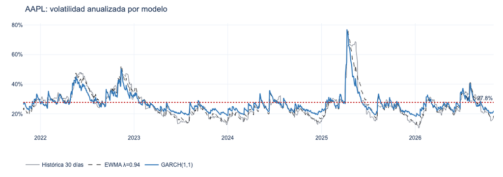

```python
PAL = dict(azul="#1f4e79", azul2="#2e75b6", verde="#2e7d32", rojo="#c62828", gris="#6b7280", oro="#b7791f")
LAY = dict(template="plotly_white", font=dict(family="Inter, Segoe UI, Arial", size=12), margin=dict(l=50, r=20, t=50, b=40),
           height=380, legend=dict(orientation="h", y=-0.22))
FIGS = {}
pctax = dict(tickformat=".0%")

f = go.Figure(go.Scatter(x=HIST.index, y=HIST.values, name="AAPL", line=dict(color=PAL["azul"])))
for val, nom, col in [(S, "Spot", PAL["gris"]), (K1, f"Conversión {PRIMA_CONV:.0%}", PAL["verde"]), (K2, f"Warrant {PRIMA_WARRANT:.0%}", PAL["rojo"])]:
    f.add_hline(y=val, line_dash="dash", line_color=col, annotation_text=f"{nom} ${val:,.0f}")
f.update_layout(title="AAPL — precio vs precios de conversión", **LAY); FIGS["precio"] = f

f = go.Figure(go.Scatter(x=list(ust_x), y=np.array(ust_y)*100, name="UST", mode="lines+markers", line=dict(color=PAL["gris"])))
UU = U.dropna(subset=["ytm"])
f.add_trace(go.Scatter(x=UU["anios"], y=UU["ytm"]*100, mode="markers", name="Bonos AAPL", text=UU["nombre"], marker=dict(color=PAL["azul2"], size=9)))
f.add_trace(go.Scatter(x=[T_BONO], y=[YTM*100], mode="markers", name="Bono elegido", marker=dict(color=PAL["rojo"], size=15, symbol="star")))
f.update_layout(title="Curva USD de Apple vs Treasuries", xaxis_title="Años", yaxis_title="Rendimiento (%)", **LAY); FIGS["curva"] = f

idx = REND.index
f = go.Figure()
f.add_trace(go.Scatter(x=idx, y=VOL_30.values, name="Histórica 30 días", line=dict(color=PAL["gris"], width=1)))
f.add_trace(go.Scatter(x=idx, y=vol_anual(V_EW), name="EWMA λ=0.94", line=dict(color="black", width=1, dash="dash")))
f.add_trace(go.Scatter(x=idx, y=vol_anual(V_G), name="GARCH(1,1)", line=dict(color=PAL["azul2"], width=2)))
f.add_hline(y=float(vol_anual(VL)), line_dash="dot", line_color=PAL["rojo"], annotation_text=f"V_L {vol_anual(VL):.1%}")
f.update_layout(title="AAPL: volatilidad anualizada por modelo", yaxis=pctax, **LAY); FIGS["vol_modelos"] = f

dd = np.arange(1, int(PLAZO_CONV*252) + 1)
f = go.Figure(go.Scatter(x=dd, y=vol_anual(pron_var(len(dd))), name="σ diaria pronosticada", line=dict(color=PAL["azul2"], width=2)))
f.add_trace(go.Scatter(x=dd, y=[vol_promedio(d) for d in dd], name="σ promedio hasta el día", line=dict(color=PAL["oro"], width=2, dash="dash")))
f.add_hline(y=float(vol_anual(VL)), line_dash="dot", line_color=PAL["rojo"], annotation_text="Largo plazo")
f.add_vline(x=HORIZON_DAYS, line_color=PAL["gris"], annotation_text="6 meses"); f.add_vline(x=int(PLAZO_CONV*252), line_color=PAL["verde"], annotation_text="6 años")
f.update_layout(title="Reversión a la media: estructura temporal GARCH", xaxis_title="Días hábiles", yaxis=pctax, **LAY); FIGS["vol_term"] = f

f = go.Figure()
if not CORR_EWMA.empty:
    f.add_trace(go.Scatter(x=CORR_60.index, y=CORR_60.values, name="Móvil 60 días", line=dict(color=PAL["gris"])))
    f.add_trace(go.Scatter(x=CORR_EWMA.index, y=CORR_EWMA.values, name="EWMA λ=0.94", line=dict(color="black", width=2)))
f.update_layout(title="Correlación AAPL – S&P 500", **LAY); FIGS["corr"] = f

dias = np.arange(HORIZON_DAYS + 1); pc = np.percentile(SIM, [5, 25, 50, 75, 95], axis=1)
f = go.Figure()
f.add_trace(go.Scatter(x=dias, y=pc[4], line=dict(width=0), showlegend=False))
f.add_trace(go.Scatter(x=dias, y=pc[0], fill="tonexty", fillcolor="rgba(46,117,182,.15)", line=dict(width=0), name="P5–P95"))
f.add_trace(go.Scatter(x=dias, y=pc[3], line=dict(width=0), showlegend=False))
f.add_trace(go.Scatter(x=dias, y=pc[1], fill="tonexty", fillcolor="rgba(46,117,182,.35)", line=dict(width=0), name="P25–P75"))
f.add_trace(go.Scatter(x=dias, y=pc[2], name="Mediana", line=dict(color=PAL["azul"], width=2)))
f.add_hline(y=S, line_dash="dot", line_color=PAL["gris"]); f.add_hline(y=K1, line_dash="dash", line_color=PAL["verde"], annotation_text="Conversión")
f.update_layout(title=f"Abanico Monte Carlo GARCH a {HORIZON_DAYS} días", xaxis_title="Días hábiles", **LAY); FIGS["abanico"] = f

ib = REND.index[INICIO_BT:]; lim = -Z_BT*np.sqrt(VG_BT[INICIO_BT:]); exc = u[INICIO_BT:] < lim
f = go.Figure(go.Scatter(x=ib, y=u[INICIO_BT:], name="Rendimiento diario (%)", line=dict(color=PAL["gris"], width=1)))
f.add_trace(go.Scatter(x=ib, y=lim, name="−VaR 99% GARCH", line=dict(color=PAL["azul2"], width=1.6)))
f.add_trace(go.Scatter(x=ib[exc], y=u[INICIO_BT:][exc], mode="markers", name="Excepciones", marker=dict(color="black", size=7)))
f.update_layout(title="Back testing del VaR 99% a 1 día", **LAY); FIGS["backtest"] = f

f = go.Figure(go.Bar(x=VOL_COMP["Volatilidad"], y=VOL_COMP["opcion_bono"], marker_color=[PAL["rojo"] if e else PAL["azul2"] for e in VOL_COMP["En uso"]],
                     text=[f"σ {s_:.1%}<br>cupón {c_:.2%}" for s_, c_ in zip(VOL_COMP["σ"], VOL_COMP["cupon"])], textposition="outside"))
f.update_layout(title="Valor de la opción de conversión por bono según la volatilidad", yaxis_title="USD por bono", **LAY); FIGS["opc_vol"] = f

f = go.Figure(go.Bar(x=EXH3["Año"], y=EXH3["Flujo"], name="Flujo", marker_color=PAL["azul2"]))
f.add_trace(go.Bar(x=EXH3["Año"], y=EXH3["VP"], name="Valor presente", marker_color=PAL["oro"]))
f.update_layout(title=f"Bono puro: cupón {C['cupon']:.2%} descontado al {YTM:.2%} → ${C['piso']:.1f}", barmode="group", yaxis_type="log", xaxis_title="Año", **LAY); FIGS["flujos"] = f

Sx = np.linspace(0.3*S, 2.5*S, 200)
f = go.Figure(go.Scatter(x=Sx, y=np.full_like(Sx, C["piso"]), name="Piso (bono puro)", line=dict(color=PAL["gris"], dash="dash")))
f.add_trace(go.Scatter(x=Sx, y=C["n"]*Sx, name="Paridad de conversión", line=dict(color=PAL["verde"], dash="dot")))
f.add_trace(go.Scatter(x=Sx, y=C["piso"] + C["n"]*bsm(Sx, C["K"], RF, SIGMA, PLAZO_CONV, Q_USO)["call"], name="Convertible", line=dict(color=PAL["azul"], width=3)))
f.add_vline(x=S, line_color=PAL["rojo"], annotation_text="Spot")
f.update_layout(title="Convertible = bono puro + calls (σ GARCH)", xaxis_title="Precio AAPL", yaxis_title="USD por bono", **LAY); FIGS["convertible"] = f

f = make_subplots(specs=[[{"secondary_y": True}]])
f.add_trace(go.Bar(x=[f"{p:.0%}" for p in SENS["Prima"]], y=SENS["opcion_bono"], name="Opción por bono", marker_color=PAL["azul2"]), secondary_y=False)
f.add_trace(go.Scatter(x=[f"{p:.0%}" for p in SENS["Prima"]], y=SENS["cupon"]*100, name="Cupón a la par (%)", line=dict(color=PAL["rojo"], width=3)), secondary_y=True)
f.update_layout(title="Menor prima → opción más valiosa → cupón más bajo", **LAY); FIGS["prima"] = f

f = go.Figure(go.Heatmap(z=HEAT.values, x=HEAT.columns, y=HEAT.index, colorscale="RdYlGn_r", text=np.round(HEAT.values, 2), texttemplate="%{text}%", colorbar=dict(title="Cupón %")))
f.update_layout(title="Cupón a la par: prima × volatilidad", xaxis_title="Volatilidad", yaxis_title="Prima", **{**LAY, "height": 420}); FIGS["heat"] = f

STg = np.linspace(0.5*S, 2.5*S, 200); pay = np.maximum(STg-K1, 0) - np.maximum(STg-K2, 0)
f = go.Figure(go.Scatter(x=STg, y=pay, name="Payoff call spread", line=dict(color=PAL["verde"], width=3)))
f.add_trace(go.Scatter(x=STg, y=pay - NETO/N_ACC*np.exp(RF*PLAZO_CONV), name="Neto de costo (VF)", line=dict(color=PAL["azul"], dash="dash")))
f.add_trace(go.Scatter(x=STg, y=np.maximum(STg-K1, 0), name="Dilución sin overlay", line=dict(color=PAL["rojo"], dash="dot")))
f.update_layout(title="Overlay: compra call 25% + venta warrant 60%", xaxis_title="AAPL al vencimiento", yaxis_title="USD por acción", **LAY); FIGS["spread"] = f

gx = bsm(Sx, C["K"], RF, SIGMA, PLAZO_CONV, Q_USO)
f = make_subplots(specs=[[{"secondary_y": True}]])
f.add_trace(go.Scatter(x=Sx, y=gx["delta_c"], name="Delta", line=dict(color=PAL["azul"])), secondary_y=False)
f.add_trace(go.Scatter(x=Sx, y=gx["vega"]*C["n"], name="Vega por bono", line=dict(color=PAL["verde"], dash="dot")), secondary_y=True)
f.update_layout(title="Griegas de la opción de conversión", xaxis_title="Precio AAPL", **LAY); FIGS["griegas"] = f

gr = np.linspace(np.percentile(ST_s, 0.5), np.percentile(ST_s, 99.5), 200)
f = make_subplots(specs=[[{"secondary_y": True}]])
f.add_trace(go.Histogram(x=ST_s, nbinsx=60, name="Distribución GARCH", marker_color="rgba(107,114,128,.35)", histnorm="probability density"), secondary_y=True)
f.add_trace(go.Scatter(x=gr, y=np.abs(gr - K_ATM) - costo_str, name="P&L straddle", line=dict(color=PAL["azul"], width=3)), secondary_y=False)
f.add_hline(y=0, line_color=PAL["gris"])
f.update_layout(title=f"Straddle ATM K={K_ATM} y distribución GARCH a 6 meses", xaxis_title="Precio al vencimiento", **LAY); FIGS["straddle"] = f
FIGS["vol_modelos"].show()
```

## 21 · Dashboard HTML (FINA 405 + caso Molson + GARCH)

```python
def fm(v, tipo="num", d=2):
    if v is None or (isinstance(v, float) and np.isnan(v)): return "n/d"
    return {"pct": f"{v*100:,.{d}f}%", "usd": f"${v:,.{d}f}", "bn": f"${v/1e9:,.1f} B", "x": f"{v:,.{d}f}x"}.get(tipo, f"{v:,.{d}f}")
def card(t, v, sub="", alerta=False):
    return f'<div class="card{" warn" if alerta else ""}"><div class="lab">{t}</div><div class="val">{v}</div><div class="sub">{sub}</div></div>'
def fuente(k): return FUENTES.get(k, "")
def esresp(k): return "respaldo" in FUENTES.get(k, "") or "SIMULADOS" in FUENTES.get(k, "")
def tabla(df): return df.to_html(classes="tbl", float_format=lambda x: f"{x:,.4f}", border=0, na_rep="n/d")
def fig(k): return f'<div class="fig">{FIGS[k].to_html(full_html=False, include_plotlyjs=False, config={"displayModeBar": False})}</div>'

ahorro_pb = (YTM - C["cupon"])*1e4
bt99 = BT[(BT["Confianza"] == "99%") & (BT["Modelo"] == "GARCH(1,1)")].iloc[0]

kpi_resumen = "".join([
    card("Bono base", "4.500% 2032", BONO["isin"]),
    card("Precio limpio", fm(precio_bono, d=3), fuente("precio_bono"), esresp("precio_bono")),
    card("YTM (tasa descuento)", fm(YTM, "pct"), "Análogo al 5.75% del caso"),
    card("Spread vs UST", f"{SPREAD*1e4:,.0f} pb", f"Dur. mod. {MOD:.2f}"),
    card("AAPL spot", fm(S, "usd"), fuente("S"), esresp("S")),
    card("σ convertible", fm(SIGMA, "pct", 1), fuente("vol")),
    card("rf 6 años", fm(RF, "pct"), fuente("rf"), esresp("ust5")),
    card("Dividend yield", fm(Q, "pct"), fuente("q"), esresp("q")),
    card("Opción conversión/bono", fm(C["opcion_bono"], "usd", 1), f"{C['n']:.3f} acc. × ${C['call_acc']:.2f}"),
    card("Bono puro", fm(C["piso"], "usd", 1), "Piso del convertible"),
    card("Cupón a la par", fm(C["cupon"], "pct"), f"Ahorro {ahorro_pb:,.0f} pb vs straight"),
    card("Call spread neto", fm(NETO/MONTO, "pct", 1), f"USD {NETO/1e6:,.1f} M · caso 8.6%"),
])
kpi_vol = "".join([
    card("α (shock)", f"{ALPHA:.4f}", "GARCH(1,1) MLE"), card("β (memoria)", f"{BETA:.4f}", f"Persistencia {ALPHA+BETA:.3f}"),
    card("Vida media shock", f"{VIDA_MEDIA:.0f} días", "ln 0.5 / ln(α+β)"),
    card("σ largo plazo", fm(float(vol_anual(VL)), "pct", 1), "V_L anualizada"),
    card("σ GARCH hoy", fm(float(vol_anual(V_NEXT)), "pct", 1), "Día siguiente"),
    card("σ histórica 1 año", fm(VOL_HIST_1A, "pct", 1), fuente("historia"), esresp("historia")),
    card("σ GARCH promedio 6 años", fm(VOL_GARCH_6A, "pct", 1), "Entra al convertible" if VOL_FUENTE == "GARCH" else "Referencia"),
    card("σ implícita ATM", fm(IV, "pct", 1), fuente("iv"), esresp("iv")),
])
kpi_riesgo = "".join([
    card("Mediana 6 meses", fm(MC["Mediana"], "usd"), f"P5 {MC['P5']:,.0f} · P95 {MC['P95']:,.0f}"),
    card("Prob. de subir", fm(MC["Prob. sube"], "pct", 1), f"μ supuesto {MU_ANUAL:.0%}"),
    card("VaR 99% 10 días", fm(MC["VaR 99% 10 días (%)"], "pct", 1), "Monte Carlo GARCH"),
    card("Kupiec VaR 99% GARCH", f"p = {bt99['p Kupiec']:.3f}", f"{bt99['Excepciones']} excepciones · {bt99['Resultado']}", bt99["p Kupiec"] < 0.05),
    card("Corr. EWMA vs S&P", fm(CORR_EWMA.iloc[-1] if not CORR_EWMA.empty else np.nan), f"Beta 1 año {BETA_MKT:.2f}"),
    card("Mejor modelo (AIC)", MEJOR_MODELO, "Hull 23.4"),
])
kpi_emp = "".join([card(k + (" (estimada)" if k == "Interest Coverage" and COB_EST else ""), fm(EMP[k], t),
                        "EBIT / (deuda × YTM)" if k == "Interest Coverage" and COB_EST else "Refinitiv") for k, t in [
    ("Market Cap", "bn"), ("Revenue (LTM)", "bn"), ("EBITDA", "bn"), ("Net Income", "bn"), ("Total Debt", "bn"), ("Cash & ST Inv.", "bn"),
    ("D/E", "x"), ("Debt/Assets", "pct"), ("Interest Coverage", "x"), ("Net Debt/EBITDA", "x"), ("EBIT Margin", "pct"), ("Net Margin", "pct")]])
kpi_pais = "".join([card("USD/CNY", fm(PAIS["USD/CNY"], d=4), "Spot"), card("China 10Y", fm(PAIS["China 10Y"], "pct"), "Gov. yield"),
                    card("US 10Y", fm(PAIS["US 10Y"], "pct"), "Treasury"), card("Diferencial CN−US", fm(PAIS["China 10Y"] - PAIS["US 10Y"], "pct"), "Puntos de tasa")])

concl = f"""
<p><b>Bono base.</b> {BONO['nombre']} ({BONO['isin']}): precio {precio_bono:.3f}, YTM {YTM:.2%}, {SPREAD*1e4:.0f} pb sobre UST,
duración modificada {MOD:.2f}. Es el análogo del bono straight a 6 años de Molson (5.75% en el caso).</p>
<p><b>Volatilidad (clase GARCH).</b> GARCH(1,1) estimado por máxima verosimilitud sobre {len(u):,} rendimientos diarios: α = {ALPHA:.3f},
β = {BETA:.3f}, persistencia {ALPHA+BETA:.3f} (un shock se diluye a la mitad en ~{VIDA_MEDIA:.0f} días). Hoy la volatilidad es {vol_anual(V_NEXT):.1%} y revierte hacia
{vol_anual(VL):.1%}; por eso la σ promedio para la vida del convertible (6 años) es <b>{VOL_GARCH_6A:.1%}</b>, frente a {VOL_HIST_1A:.1%} histórica de 1 año
y {IV:.1%} implícita. El mejor modelo por AIC es <i>{MEJOR_MODELO}</i>. Usar la σ de hoy subestimaría la opción: GARCH justifica una σ de largo plazo.</p>
<p><b>Convertible sintético a {PLAZO_CONV:.0f} años, prima {PRIMA_CONV:.0%}.</b> Con σ = {SIGMA:.1%} la opción vale ${C['opcion_bono']:.1f} por bono
({C['n']:.3f} acciones a ${C['K']:.2f}); el bono puro debe valer ${C['piso']:.1f}, lo que exige un cupón de <b>{C['cupon']:.2%}</b> vs {YTM:.2%} straight:
ahorro de {ahorro_pb:.0f} pb (≈ USD {(YTM-C['cupon'])*MONTO/1e6:,.1f} M al año sobre USD {MONTO/1e9:.1f} B). El árbol CRR americano agrega solo
${(am_['precio']-eu_)*C['n']:.2f} por bono de prima de ejercicio anticipado (q = {Q:.2%} ≪ r = {RF:.2%}), y el Monte Carlo GARCH (Duan) da
${MC_CALL*C['n']:.1f}: Black-Scholes es una aproximación válida, igual que en el caso.</p>
<p><b>Riesgo.</b> Para el inversionista, el VaR 99% a 10 días de la acción es {MC['VaR 99% 10 días (%)']:.1%}; el back testing del VaR 99% GARCH
{'pasa' if bt99['p Kupiec'] > 0.05 else 'no pasa'} la prueba de Kupiec (p = {bt99['p Kupiec']:.3f}). La dilución potencial es de solo
{fm(EMP.get('Dilución conv. 25%'), 'pct')} de las acciones: para Apple el convertible es una herramienta de costo, no de capital.</p>
<p><b>Call spread.</b> Note hedge {COSTO_HEDGE/MONTO:.1%} − warrants {INGRESO_WARR/MONTO:.1%} = costo neto <b>{NETO/MONTO:.1%}</b> del principal (caso: 8.6%).
Emitir directo al 60% exigiría cupón {C60['cupon']:.2%}; el VP de ese cupón extra (USD {VP_EXTRA/1e6:,.1f} M) frente al costo del spread (USD {NETO/1e6:,.1f} M)
confirma el punto del caso: <i>no hay free lunch</i>.</p>
<p><b>Estrategia de volatilidad.</b> σ GARCH 6m {VOL_GARCH_6M:.1%} vs implícita {IV:.1%} (razón {RATIO_VOL:.2f}): {SENAL}.
Straddle ATM K={K_ATM}: costo {STRADDLE['costo']:.2f}, P&L esperado {STRADDLE['pnl_esp']:.2f}, probabilidad de ganar {STRADDLE['prob_gan']:.0%}.</p>
<p><b>Limitaciones.</b> GARCH(1,1) supone normalidad y no capta asimetría (GJR/EGARCH); μ es un supuesto; el bono real tiene make-whole call
(Molson era non-call life) y Apple no tiene convertibles: es una emisión hipotética.</p>"""
```

```python
tabs = [
 ("Resumen", f'<div class="grid">{kpi_resumen}</div><div class="two">{fig("convertible")}{fig("precio")}</div>'),
 ("Bonos AAPL", f'<p class="nota">Fuente: {FUENTE_UNIV}. Puntaje = cercanía a 6 años y a la par.</p>{fig("curva")}'
     + tabla(U.sort_values("puntaje", ascending=False)[["nombre", "cusip", "isin", "cupon", "vencimiento", "anios", "precio", "ytm", "puntaje"]].reset_index(drop=True))),
 ("Empresa & País", f'<h3>Apple Inc. — perfil financiero</h3><div class="grid">{kpi_emp}</div><h3>Contexto China</h3><div class="grid">{kpi_pais}</div>'),
 ("Volatilidad GARCH", f'<div class="grid">{kpi_vol}</div><div class="two">{fig("vol_modelos")}{fig("vol_term")}</div>'
     f'<h3>Parámetros y validación</h3><p class="nota">{ARCH_CHECK}</p>{tabla(GARCH_TAB.to_frame("AAPL"))}'
     f'<h3>Elección de modelo (Hull 23.4)</h3>{tabla(COMPAR.set_index("Modelo"))}<h3>Estructura temporal</h3>{tabla(EST_TEMP)}'),
 ("Riesgo & VaR", f'<div class="grid">{kpi_riesgo}</div><div class="two">{fig("abanico")}{fig("backtest")}</div>{fig("corr")}'
     f'<h3>Back testing (Kupiec)</h3>{tabla(BT.set_index(["Confianza", "Modelo"]))}<h3>Monte Carlo GARCH</h3>{tabla(MC.to_frame("AAPL"))}'),
 ("Opción de conversión", f'{fig("opc_vol")}{tabla(VOL_COMP.set_index("Volatilidad"))}'
     f'<h3>Exhibit 2 — Black-Scholes-Merton (q = {Q_USO:.2%})</h3>{tabla(EXH2)}'
     f'<h3>Americana (árbol CRR, N={N_ARBOL}) y Monte Carlo GARCH</h3>{tabla(AMER)}{tabla(GRIEGAS_CRR.to_frame("Griegas CRR americana (por acción)"))}{fig("griegas")}'),
 ("Bono puro & cupón", f'<h3>Exhibit 3</h3>{fig("flujos")}{tabla(EXH3)}<p class="nota">Convertible = ${C["piso"]:.2f} + ${C["opcion_bono"]:.2f} = ${C["piso"]+C["opcion_bono"]:.2f}</p>'),
 ("Sensibilidades", f'<div class="two">{fig("prima")}{fig("heat")}</div>{tabla(SENS)}'),
 ("Call spread", f'<h3>Exhibits 1 y 4</h3>{tabla(EXH4)}{fig("spread")}<p class="nota">Cupón directo al {PRIMA_WARRANT:.0%}: {C60["cupon"]:.3%} · σ warrant {VOL_W:.1%}</p>'),
 ("Estrategia volatilidad", f'<p><b>Señal:</b> {SENAL} (σ GARCH 6m {VOL_GARCH_6M:.1%} / σ implícita {IV:.1%} = {RATIO_VOL:.2f})</p>'
     f'{fig("straddle")}{tabla(OPC_ATM.set_index("Volatilidad"))}<p class="nota">Puntos de equilibrio {STRADDLE["be_inf"]:.2f} y {STRADDLE["be_sup"]:.2f}</p>'),
 ("Validación Molson", f'<p class="nota">El modelo reproduce los exhibits del caso con sus mismos supuestos.</p>{tabla(VALID.set_index("Concepto"))}'),
 ("Conclusiones", concl),
]
nav = "".join(f'<button class="tab{" on" if i == 0 else ""}" onclick="ver({i})">{t}</button>' for i, (t, _) in enumerate(tabs))
body = "".join(f'<section id="s{i}" style="display:{"block" if i == 0 else "none"}">{c}</section>' for i, (_, c) in enumerate(tabs))
fuentes_txt = " · ".join(f"{k}: {v}" for k, v in FUENTES.items() if not k.startswith("emp_"))
aviso = '<div class="aviso">⚠ Vista generada con datos simulados/respaldo — no son datos de mercado. Corre el notebook con tu sesión de Refinitiv.</div>' if esresp("historia") else ""

HTML = f"""<!doctype html><html lang="es"><head><meta charset="utf-8"><meta name="viewport" content="width=device-width,initial-scale=1">
<title>AAPL Convertible GARCH</title><script src="https://cdn.plot.ly/plotly-2.35.2.min.js"></script>
<style>
:root{{--bg:#f5f7fa;--card:#fff;--ink:#1a202c;--mut:#6b7280;--acc:#1f4e79;--warn:#b45309}}
body{{margin:0;background:var(--bg);color:var(--ink);font-family:Inter,Segoe UI,Arial,sans-serif}}
header{{background:linear-gradient(135deg,#0f2742,#1f4e79);color:#fff;padding:22px 28px}}
header h1{{margin:0;font-size:22px}} header p{{margin:4px 0 0;opacity:.85;font-size:13px}}
.aviso{{background:#fef3c7;color:#92400e;padding:10px 28px;font-size:13px;font-weight:600}}
nav{{display:flex;flex-wrap:wrap;gap:6px;padding:12px 28px;background:#fff;border-bottom:1px solid #e5e7eb;position:sticky;top:0;z-index:5}}
.tab{{border:1px solid #d1d5db;background:#fff;border-radius:18px;padding:6px 14px;cursor:pointer;font-size:13px;color:var(--ink)}}
.tab.on{{background:var(--acc);color:#fff;border-color:var(--acc)}}
main{{padding:20px 28px;max-width:1400px;margin:auto}}
.grid{{display:grid;grid-template-columns:repeat(auto-fill,minmax(200px,1fr));gap:12px;margin-bottom:18px}}
.card{{background:var(--card);border-radius:10px;padding:14px 16px;box-shadow:0 1px 3px rgba(0,0,0,.08);border-left:4px solid var(--acc)}}
.card.warn{{border-left-color:var(--warn)}} .lab{{font-size:12px;color:var(--mut);text-transform:uppercase;letter-spacing:.04em}}
.val{{font-size:22px;font-weight:700;margin:4px 0}} .sub{{font-size:11px;color:var(--mut)}}
.two{{display:grid;grid-template-columns:repeat(auto-fit,minmax(min(480px,100%),1fr));gap:14px}}
.fig{{background:#fff;border-radius:10px;padding:6px;margin-bottom:14px}}
table{{border-collapse:collapse;background:#fff;font-size:12.5px;margin:10px 0 18px;width:100%;overflow-x:auto;display:block}}
th,td{{padding:6px 10px;border-bottom:1px solid #eef0f3;text-align:right;white-space:nowrap}} th{{background:#f0f4f8;color:#334155}}
h3{{margin:18px 0 6px;color:#0f2742}} .nota{{font-size:12.5px;color:var(--mut)}} section p{{line-height:1.55;max-width:1050px}}
footer{{font-size:11px;color:var(--mut);padding:16px 28px}}
@media(max-width:600px){{main,nav,header,.aviso{{padding-left:16px;padding-right:16px}}}}
</style></head><body>
<header><h1>Apple Inc. (AAPL) — Bono Convertible Sintético con volatilidad GARCH</h1>
<p>{CURSO} · {AUTORES} · Base: caso Molson Coors (NE90-06-107) + Hull caps. 13, 22 y 23 · Datos: Refinitiv/LSEG · {HOY:%d-%b-%Y}</p></header>
{aviso}<nav>{nav}</nav><main>{body}</main>
<footer>Fuentes: {fuentes_txt}. Las tarjetas con borde ámbar usan valores de respaldo. Material académico; no es recomendación de inversión.</footer>
<script>function ver(i){{document.querySelectorAll("section").forEach((s,j)=>s.style.display=j==i?"block":"none");
document.querySelectorAll(".tab").forEach((b,j)=>b.classList.toggle("on",j==i));window.dispatchEvent(new Event("resize"));}}</script>
</body></html>"""

RUTA = os.path.join(CARPETA, "AAPL_Convertible_GARCH_Dashboard.html")
with open(RUTA, "w", encoding="utf-8") as fh: fh.write(HTML)
print("Dashboard guardado en:", os.path.abspath(RUTA))
from IPython.display import IFrame, display
display(IFrame(src=RUTA, width="100%", height=900))
```

```
Dashboard guardado en: /Users/francoflores/lseg-project/Ciencia de Datos/sesion8/DERIVATIVES/AAPL_Convertible_GARCH_Dashboard.html
```

[interactive chart not shown]

## 22 · Exportar tablas a Excel

```python
RUTA_XLSX = os.path.join(CARPETA, "AAPL_Convertible_GARCH_Tablas.xlsx")
with pd.ExcelWriter(RUTA_XLSX, engine="openpyxl") as xw:
    for nombre, df_, idx_ in [("Universo_bonos", U, False), ("GARCH_parametros", GARCH_TAB.to_frame("AAPL"), True),
                              ("Eleccion_modelo", COMPAR, False), ("Estructura_vol", EST_TEMP, True), ("MonteCarlo", MC.to_frame("AAPL"), True),
                              ("Backtest_VaR", BT, False), ("Vol_vs_opcion", VOL_COMP, False), ("Exhibit2_Opcion", EXH2, True),
                              ("Americana_CRR_MC", AMER, True), ("Exhibit3_Bono", EXH3, False), ("Sensibilidad_prima", SENS, False),
                              ("Heatmap_cupon", HEAT, True), ("Exhibit4_CallSpread", EXH4, True), ("Opcion_ATM_6m", OPC_ATM, False),
                              ("Validacion_Molson", VALID, False), ("Fuentes", pd.Series(FUENTES).to_frame("Fuente"), True)]:
        df_.to_excel(xw, sheet_name=nombre, index=idx_)
print("Excel exportado en:", os.path.abspath(RUTA_XLSX))
```

```
Excel exportado en: /Users/francoflores/lseg-project/Ciencia de Datos/sesion8/DERIVATIVES/AAPL_Convertible_GARCH_Tablas.xlsx
```

## 23 · Descargar el dashboard y el notebook completo en HTML

Guarda el notebook (**Cmd+S**) antes de correr esta celda para que el HTML del código incluya las últimas salidas.

```python
import glob, base64, shutil
from pathlib import Path
from IPython.display import HTML as _HTML

DESCARGAS = Path.home()/"Downloads"; DESCARGAS.mkdir(exist_ok=True)
dash = Path(RUTA).resolve(); dash_dest = DESCARGAS/dash.name; shutil.copy(dash, dash_dest)

nb = next((Path(p).resolve() for p in sorted(glob.glob("*.ipynb"), key=os.path.getmtime, reverse=True)
           if "VOL_GARCH_6A" in open(p, encoding="utf-8").read()), None)
nb_html = None
if nb is None:
    print("⚠ No encontré el .ipynb en esta carpeta; solo se descarga el dashboard.")
else:
    res = subprocess.run([sys.executable, "-m", "jupyter", "nbconvert", "--to", "html", "--output", f"{nb.stem}_codigo",
                          "--output-dir", str(DESCARGAS), str(nb)], capture_output=True, text=True)
    nb_html = DESCARGAS/f"{nb.stem}_codigo.html"
    if res.returncode != 0: print(res.stderr[-800:]); nb_html = None

def boton(ruta, texto):
    b64 = base64.b64encode(Path(ruta).read_bytes()).decode()
    return (f'<a download="{Path(ruta).name}" href="data:text/html;base64,{b64}" style="display:inline-block;margin:6px 10px 6px 0;'
            f'padding:10px 18px;background:#1f4e79;color:#fff;border-radius:8px;text-decoration:none;font-weight:600">⬇ {texto}</a>')
display(_HTML(boton(dash_dest, "Descargar dashboard HTML") + (boton(nb_html, "Descargar notebook completo HTML") if nb_html else "")))
print("Copiados en Descargas:", dash_dest, nb_html or "")
```

⬇ Descargar dashboard HTML⬇ Descargar notebook completo HTML

```
Copiados en Descargas: /Users/francoflores/Downloads/AAPL_Convertible_GARCH_Dashboard.html /Users/francoflores/Downloads/AAPL_Convertible_GARCH_Proyecto_codigo.html
```

```python
!jupyter nbconvert --to html AAPL_Convertible_GARCH_Proyecto.ipynb
```

```
[NbConvertApp] Converting notebook AAPL_Convertible_GARCH_Proyecto.ipynb to html
[NbConvertApp] WARNING | Alternative text is missing on 1 image(s).
[NbConvertApp] Writing 2811406 bytes to AAPL_Convertible_GARCH_Proyecto.html
```

```python
!open AAPL_Convertible_GARCH_Proyecto.html
```